# Lesson 4 - Part 1 : Simulation

ZYY

2021年6月19日

# str(): Structure

- A diagnostic fuction and an alternative to **sumary()**.
- Particularly suited to **compactly display** large lists which may contain nested lists.

```r
str(str)
```

```
## function (object, ...)
```

```r
str(lm)
```

```
## function (formula, data, subset, weights, na.action, method = "qr", model = TRUE,
##     x = FALSE, y = FALSE, qr = TRUE, singular.ok = TRUE, contrasts = NULL,
##     offset, ...)
```

```r
x<-rnorm(100,2,4)
summary(x)
```

```
##     Min.  1st Qu.   Median     Mean  3rd Qu.     Max.
## -6.64661  0.06001  1.57847  2.01216  4.01372 12.39595
```

```r
str(x)
```

```
##  num [1:100] 4.4 1.03 6.26 1.14 9.03 ...
```

```r
#factor
f<-gl(40,10)
summary(f)
```

```
##  1  2  3  4  5  6  7  8  9 10 11 12 13 14 15 16 17 18 19 20 21 22 23 24 25 26
## 10 10 10 10 10 10 10 10 10 10 10 10 10 10 10 10 10 10 10 10 10 10 10 10 10 10
## 27 28 29 30 31 32 33 34 35 36 37 38 39 40
## 10 10 10 10 10 10 10 10 10 10 10 10 10 10
```

```r
str(f)
```

```
##  Factor w/ 40 levels "1","2","3","4",..: 1 1 1 1 1 1 1 1 1 1 ...
```

```r
#dataframe
library(datasets)
head(airquality)
```

```
##   Ozone Solar.R Wind Temp Month Day
## 1    41     190  7.4   67     5   1
## 2    36     118  8.0   72     5   2
## 3    12     149 12.6   74     5   3
## 4    18     313 11.5   62     5   4
## 5    NA      NA 14.3   56     5   5
## 6    28      NA 14.9   66     5   6
```

```r
str(airquality)
```

```
## 'data.frame':    153 obs. of  6 variables:
##  $ Ozone  : int  41 36 12 18 NA 28 23 19 8 NA ...
##  $ Solar.R: int  190 118 149 313 NA NA 299 99 19 194 ...
##  $ Wind   : num  7.4 8 12.6 11.5 14.3 14.9 8.6 13.8 20.1 8.6 ...
##  $ Temp   : int  67 72 74 62 56 66 65 59 61 69 ...
##  $ Month  : int  5 5 5 5 5 5 5 5 5 5 ...
##  $ Day    : int  1 2 3 4 5 6 7 8 9 10 ...
```

```r
#matrix
m<-matrix(rnorm(100),10,10)
str(m)
```

```
##  num [1:10, 1:10] -1.9563 1.1346 -1.3146 -1.4882 -0.0844 ...
```

```r
m[,1]
```

```
##  [1] -1.95631372  1.13463705 -1.31462514 -1.48815416 -0.08442316 -0.08668933
##  [7] -0.70216909 -0.44559318  0.76115201 -1.46060464
```

```r
s<-split(airquality,airquality$Month)
str(s)
```

```
## List of 5
##  $ 5:'data.frame':   31 obs. of  6 variables:
##   ..$ Ozone  : int [1:31] 41 36 12 18 NA 28 23 19 8 NA ...
##   ..$ Solar.R: int [1:31] 190 118 149 313 NA NA 299 99 19 194 ...
##   ..$ Wind   : num [1:31] 7.4 8 12.6 11.5 14.3 14.9 8.6 13.8 20.1 8.6 ...
##   ..$ Temp   : int [1:31] 67 72 74 62 56 66 65 59 61 69 ...
##   ..$ Month  : int [1:31] 5 5 5 5 5 5 5 5 5 5 ...
##   ..$ Day    : int [1:31] 1 2 3 4 5 6 7 8 9 10 ...
##  $ 6:'data.frame':   30 obs. of  6 variables:
##   ..$ Ozone  : int [1:30] NA NA NA NA NA NA 29 NA 71 39 ...
##   ..$ Solar.R: int [1:30] 286 287 242 186 220 264 127 273 291 323 ...
##   ..$ Wind   : num [1:30] 8.6 9.7 16.1 9.2 8.6 14.3 9.7 6.9 13.8 11.5 ...
##   ..$ Temp   : int [1:30] 78 74 67 84 85 79 82 87 90 87 ...
##   ..$ Month  : int [1:30] 6 6 6 6 6 6 6 6 6 6 ...
##   ..$ Day    : int [1:30] 1 2 3 4 5 6 7 8 9 10 ...
##  $ 7:'data.frame':   31 obs. of  6 variables:
##   ..$ Ozone  : int [1:31] 135 49 32 NA 64 40 77 97 97 85 ...
##   ..$ Solar.R: int [1:31] 269 248 236 101 175 314 276 267 272 175 ...
##   ..$ Wind   : num [1:31] 4.1 9.2 9.2 10.9 4.6 10.9 5.1 6.3 5.7 7.4 ...
##   ..$ Temp   : int [1:31] 84 85 81 84 83 83 88 92 92 89 ...
##   ..$ Month  : int [1:31] 7 7 7 7 7 7 7 7 7 7 ...
##   ..$ Day    : int [1:31] 1 2 3 4 5 6 7 8 9 10 ...
##  $ 8:'data.frame':   31 obs. of  6 variables:
##   ..$ Ozone  : int [1:31] 39 9 16 78 35 66 122 89 110 NA ...
##   ..$ Solar.R: int [1:31] 83 24 77 NA NA NA 255 229 207 222 ...
##   ..$ Wind   : num [1:31] 6.9 13.8 7.4 6.9 7.4 4.6 4 10.3 8 8.6 ...
##   ..$ Temp   : int [1:31] 81 81 82 86 85 87 89 90 90 92 ...
##   ..$ Month  : int [1:31] 8 8 8 8 8 8 8 8 8 8 ...
##   ..$ Day    : int [1:31] 1 2 3 4 5 6 7 8 9 10 ...
##  $ 9:'data.frame':   30 obs. of  6 variables:
##   ..$ Ozone  : int [1:30] 96 78 73 91 47 32 20 23 21 24 ...
##   ..$ Solar.R: int [1:30] 167 197 183 189 95 92 252 220 230 259 ...
##   ..$ Wind   : num [1:30] 6.9 5.1 2.8 4.6 7.4 15.5 10.9 10.3 10.9 9.7 ...
##   ..$ Temp   : int [1:30] 91 92 93 93 87 84 80 78 75 73 ...
##   ..$ Month  : int [1:30] 9 9 9 9 9 9 9 9 9 9 ...
##   ..$ Day    : int [1:30] 1 2 3 4 5 6 7 8 9 10 ...
```

# Simulation

- **rnorm**: generate random **Normal** variates with a given **mean** and **standard deviation**.
- **dnorm**: evaluate the **Normal probability density** (with a given mean/SD) at a point (or vector of points)
- **pnorm**: evaluate the **cumulative distribution** function for a Normal distribution
- **rpois**: generate random **Poisson** variates with a given rate.

> Probability distribution functions usually have four functions associated with them:

Standard distributions are built in: Normal, Poisson, Binomial, Exponential, Gamma, etc. * **d** for density * **r** for random number generation * **p** for cumulative distribution * **q** for quantile function

```r
#dnorm(x, mean = 0, sd = 1, log = FALSE)
#pnorm(q, mean = 0, sd = 1, lower.tail = TRUE, log.p = FALSE)
#qnorm(p, mean = 0, sd = 1, lower.tail = TRUE, log.p = FALSE)
#rnorm(n, mean = 0, sd = 1)
x <- rnorm(10)
x
```

```
##  [1]  0.0123091  0.1905628  0.5066601  1.4695375 -0.3809758 -0.1953734
##  [7]  1.6759901  0.2097400 -1.2639101  1.2902941
```

```r
x <- rnorm(10, 20, 2)
x
```

```
##  [1] 18.48970 18.82991 21.41377 23.77122 19.71617 18.97390 18.20097 19.08835
##  [9] 20.17873 15.80817
```

```r
summary(x)
```

```
##    Min. 1st Qu.  Median    Mean 3rd Qu.    Max.
##   15.81   18.57   19.03   19.45   20.06   23.77
```

## **set.seed()**: ensures reproducibility.

Always set the random number seed when conducting a simulation!

```r
set.seed(1)
rnorm(5)
```

```
## [1] -0.6264538  0.1836433 -0.8356286  1.5952808  0.3295078
```

```r
rnorm(5)
```

```
## [1] -0.8204684  0.4874291  0.7383247  0.5757814 -0.3053884
```

```r
set.seed(1)
rnorm(5)#After reset the seed, the random number can be reproduced.
```

```
## [1] -0.6264538  0.1836433 -0.8356286  1.5952808  0.3295078
```

## Poisson data

```r
rpois(10, 1)
```

```
##  [1] 0 0 1 1 2 1 1 4 1 2
```

```r
rpois(10, 2)
```

```
##  [1] 4 1 2 0 1 1 0 1 4 1
```

```r
rpois(10, 20)
```

```
##  [1] 19 19 24 23 22 24 23 20 11 22
```

```r
ppois(2, 2)
```

```
## [1] 0.6766764
```

```r
ppois(4, 2)
```

```
## [1] 0.947347
```

```r
ppois(6, 2)
```

```
## [1] 0.9954662
```

## Generating random numbers from a linear model

Suppose we want to simulate from the following linear model:

y = β0 + β1x + ε

```r
set.seed(20)
x <- rnorm(100)
e <- rnorm(100, 0, 2)
y <- 0.5 + 2 * x + e
summary(y)
```

```
##    Min. 1st Qu.  Median    Mean 3rd Qu.    Max.
## -6.4084 -1.5402  0.6789  0.6893  2.9303  6.5052
```

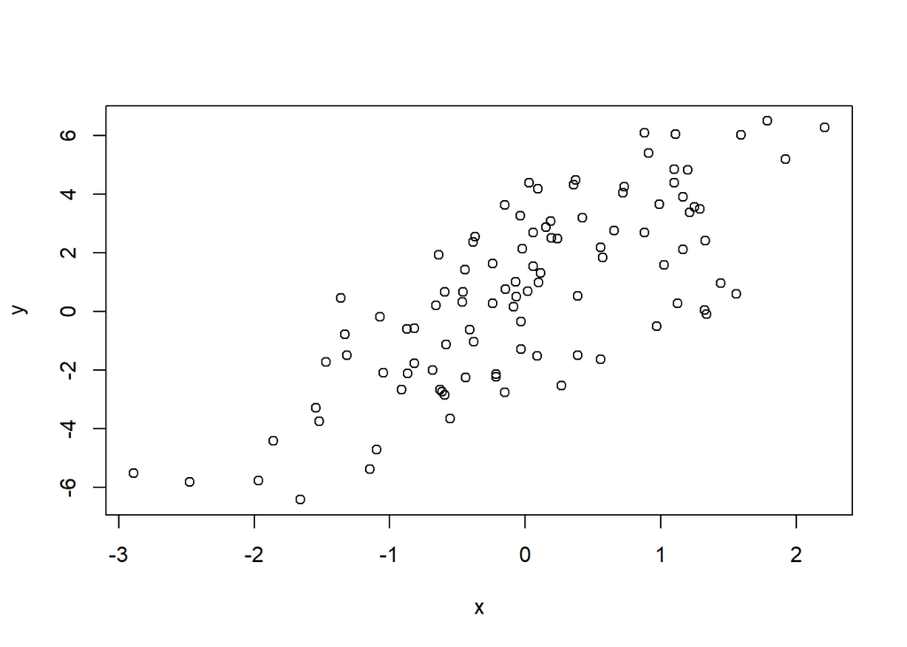

```r
plot(x, y)
```

What if x is binary?

```r
set.seed(10)
x <- rbinom(100, 1, 0.5)
e <- rnorm(100, 0, 2)
y <- 0.5 + 2 * x + e
summary(y)
```

```
##    Min. 1st Qu.  Median    Mean 3rd Qu.    Max.
## -3.4936 -0.1409  1.5767  1.4322  2.8397  6.9410
```

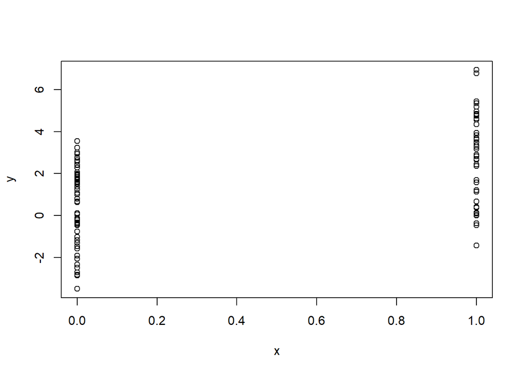

```r
plot(x, y)
```

Suppose we want to simulate from a **Poisson** model where

Y ~ Poisson(μ)

log μ = β0 + β1x and β0 = 0.5 and β1=0.3 . We need to use the **rpois** function for this

```r
set.seed(1)
x <- rnorm(100)
log.mu <- 0.5 + 0.3 * x
y <- rpois(100, exp(log.mu))
summary(y)
```

```
##    Min. 1st Qu.  Median    Mean 3rd Qu.    Max.
##    0.00    1.00    1.00    1.55    2.00    6.00
```

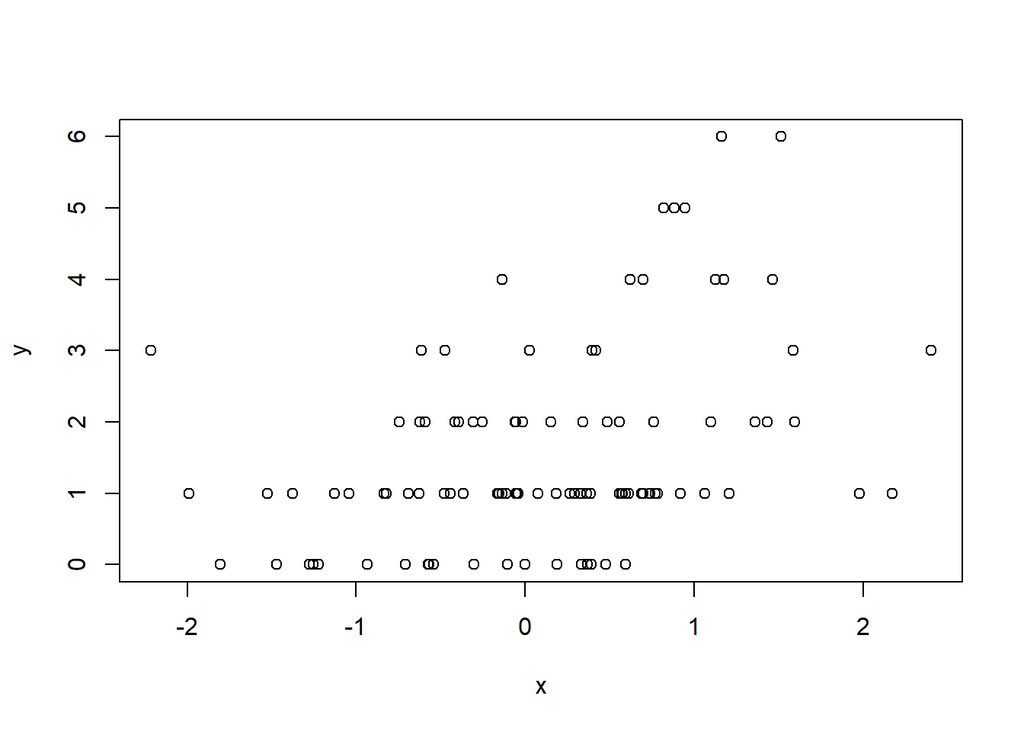

```r
plot(x, y)
```

## Random sampling

The **sample** function draws randomly from a specified set of (scalar) objects allowing you to sample from arbitrary distributions.

```r
set.seed(1)
sample(1:10, 4)
```

```
## [1] 9 4 7 1
```

```r
sample(1:10, 4)
```

```
## [1] 2 7 3 6
```

```r
sample(letters, 5)
```

```
## [1] "r" "s" "a" "u" "w"
```

```r
sample(1:10) ## permutation
```

```
##  [1] 10  6  9  2  1  5  8  4  3  7
```

```r
sample(1:10, replace = TRUE) ## Sample w/replacement
```

```
##  [1]  5  5  2 10  9  1  4  3  6 10
```